# OOP

Dr. Wayne Stewart

2019-10-15

# 1 Introduction:

OOP means: Object Oriented Programming.

This mini lab is about understanding one of the object oriented approaches or systems available to R users (There are a number of them S3, S4 plus others that come in packages).

You can read more about the S3 and other OOP formats here: https://adv-r.hadley.nz/s3.html install the package `sloop` before trying the code in the link.

## 1.1 Function overloading

The idea here is that the way the function operates and processes input depends on the nature (“the class”) of the object.

Example:

```r
v1 = rep(c(TRUE,FALSE,TRUE), c(3,5,6))
class(v1)
```

```
## [1] "logical"
```

```r
summary(v1)
```

```
##    Mode   FALSE    TRUE
## logical       5       9
```

Here `v1` is a vector of logical values. It is `atomic` consisting of values of the same type.

Summary does the sensible thing – but how does R know how to change its summary methods?

Look at this example

```r
v2 = rnorm(100,mean=50,sd=20)
class(v2)
```

```
## [1] "numeric"
```

```r
summary(v2)
```

```
##    Min. 1st Qu.  Median    Mean 3rd Qu.    Max.
##   9.429  39.896  51.211  52.544  65.750  91.494
```

In both examples we used the function `summary()`, the only difference was that the object changed – the output was `fundamentally` different as it should be. The objects `v1` and `v2` were of different classes - the first `logical` and the other `numeric`. The summary function inspected the class of the object and dispatched the correct method to process the object.

## 1.2 OOP Supports:

> 1. Objects
> 2. Classes
> 3. Inheritance
> 4. Polymorphism

The above can be examined in more detail but we will understand these concepts by looking at an example.

## 1.3 S3 System

We will only be using the S3 version of OOP which is the most common form of OOP in R and R packages.

#How it works

We will now discuss the basics of how this system works.

The main idea is the creation of an object through a constructor function. This is just a regular function that produces an object that has a special attribute called a `class`.

This function will, when used create objects of this class and what we want to do is operate on these objects with other functions called `generic functions`. These `generic functions` will detect the `class` of an object and then dispatch the correct `method` by inspecting the `class` attribute.

This seems a little complicated so lets do an example.

# 2 Example

S3 OOP is likely something you have already observed without knowing the precise mechanisms used.

Take for example an object made by the constructor function `lm()`. We will install and make available the `s20x` package which contains data and functions we may wish to use.

```r
if(!require(s20x)) install.packages("s20x")
x<-1:30
y<-8+3*x + rnorm(30,0,10)
```

Now lets use a constructor function:

```r
obj=lm(y~x)
```

Notice that the function `lm()` has been used with some input options to produce the object `obj`

What is its class?

```r
class(obj)
```

```
## [1] "lm"
```

There are functions that we can use to operate on the obj which will be especially suited to handle this particular class. Example `summary`

```r
summary(obj)
```

```
##
## Call:
## lm(formula = y ~ x)
##
## Residuals:
##      Min       1Q   Median       3Q      Max
## -20.4499  -3.9707   0.9581   4.3820  19.1214
##
## Coefficients:
##             Estimate Std. Error t value Pr(>|t|)
## (Intercept)   9.4431     3.8332   2.463   0.0202 *
## x             2.9113     0.2159  13.483 9.09e-14 ***
## ---
## Signif. codes:  0 '***' 0.001 '**' 0.01 '*' 0.05 '.' 0.1 ' ' 1
##
## Residual standard error: 10.24 on 28 degrees of freedom
## Multiple R-squared:  0.8665, Adjusted R-squared:  0.8618
## F-statistic: 181.8 on 1 and 28 DF,  p-value: 9.086e-14
```

# 3 Generic functions

To see what methods are available for the class `lm` we can invoke the function `methods`

```r
methods(class = "lm")
```

```
##  [1] add1           alias          anova          case.names
##  [5] coerce         confint        cooks.distance deviance
##  [9] dfbeta         dfbetas        drop1          dummy.coef
## [13] effects        eovcheck       extractAIC     family
## [17] formula        hatvalues      influence      initialize
## [21] kappa          labels         logLik         modcheck
## [25] model.frame    model.matrix   nobs           normcheck
## [29] onewayPlot     plot           predict        print
## [33] proj           qr             residuals      rstandard
## [37] rstudent       show           simulate       slotsFromS3
## [41] summary        variable.names vcov
## see '?methods' for accessing help and source code
```

We can choose any of these functions (methods) to operate on the `lm` object and by this way we have a modular system of programming where we can use inheritance and take advantage of objects with a particular class.

Lets pick a method above and use it for fun. Say, `normcheck`

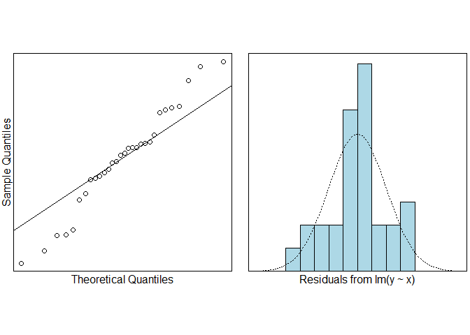

```r
normcheck(obj)
```

It would we be nice to be able to send additional options to the method function as well.

This will be facilitated when we create the generic function by using the ellipsis `...`.

By the way here are the `normcheck` method functions for all the classes on the machine

```r
methods("normcheck")
```

```
## [1] normcheck.default* normcheck.lm*
## see '?methods' for accessing help and source code
```

Notice there are only two of them - one for a default class and the other for `lm`.

Try another,

```r
methods("predict")
```

```
##  [1] predict.ar*                predict.Arima*
##  [3] predict.arima0*            predict.glm
##  [5] predict.HoltWinters*       predict.lm
##  [7] predict.loess*             predict.mlm*
##  [9] predict.nls*               predict.poly*
## [11] predict.ppr*               predict.prcomp*
## [13] predict.princomp*          predict.smooth.spline*
## [15] predict.smooth.spline.fit* predict.StructTS*
## see '?methods' for accessing help and source code
```

A lot more for `predict` – in all cases we see the following format:

`method.class`

Notice that there is a method `predict.lm` which will operate on an object of class `lm`.

#What happens

When the function `normcheck()` (a generic function) inspects the object `normcheck(obj)` it dispatches the appropiate method `normcheck.lm`.

The actual function that operates on the object is `normcheck.lm()`.

# 4 An example from the ground up

Suppose we wish to analyze data that is suitable for SLR (Simple Linear Regression).

## 4.1 The function

The first thing we shall do is make a constructor function. This function will make an object of a new class that we will make methods for.

```r
math4753Reg = function(df,x,y)
  {
 require(ggplot2) # we need this package

  g = ggplot(df, aes_string(x=x,y=y))
  g = g + geom_point()
  g = g + geom_smooth(method="lm", formula=y~x)

  eqn <- paste0(y,"~", x) # repalce x,y with called values
  ylm = lm(eqn,data=df) # lm object formed

stuff = list(df=df, ylm=ylm,g=g) # stuff is a list of class `list`

class(stuff)=append(class(stuff),"math4753Reg") # stuff is now a list of class `list` and `math4753Reg`
return(stuff)
}
```

The above function makes a list object, this will have an existing class `list` and this is appended by the use of `append` so that any object made with the function will have two classes associated with it , `list` and `math4753Reg`.

We can take advantage of both classes – that is we can operate on this object and inherit methods from both classes if we wish.

We will now read in the ddt data set:

```r
ddt = read.csv("DDT.csv")
head(ddt,2)
```

```
##   RIVER MILE  SPECIES LENGTH WEIGHT DDT
## 1   FCM    5 CCATFISH   42.5    732  10
## 2   FCM    5 CCATFISH   44.0    795  16
```

## 4.2 Making the object

We will make a new object - that has the new class appended to it.

```r
yreg  = math4753Reg(df = ddt, x = "WEIGHT", y = "LENGTH")
```

What is the class of this object?

```r
class(yreg)
```

```
## [1] "list"        "math4753Reg"
```

We wish to use the second class in conjunction with a generic function to dispatch an appropriate method.

## 4.3 Lets make our own generic function

If we examine an existing base R generic function like `print` this is what we see:

```r
print
```

```
## function (x, ...)
## UseMethod("print")
## <bytecode: 0x00000000142ff530>
## <environment: namespace:base>
```

Notice that the function is made with an object `x` and an `ellipsis`. The body of the function invokes the function `UseMethod()`.

We will use exactly the same format to create our own generic functions.

```r
rsq<- function(x,...)
{
  #print("Calling the base math4753Reg function")
  UseMethod("rsq")
}
```

How does the `UseMethod` function work?

The following is taken directly from the R help file.

When a function calling UseMethod(“fun”) is applied to an object with class attribute c(“first”, “second”), the system searches for a function called fun.first and, if it finds it, applies it to the object. If no such function is found a function called fun.second is tried.

If no class name produces a suitable function, the function fun.default is used, if it exists, or an error results.

```r
rsq.default <- function(x,...)
{
  print("There is no `rsq` method for this class!! Sadness!")
  return(x)
}
```

```r
rsq.math4753Reg <- function(x, ...)
{

  sm=summary(x$ylm,...)

  sm$r.squared
}
```

Notice that the constructor function produces an object with two classes, `list` and `math4753Reg`. We could have created a method with the name `rsq.list`. This means of course that there is the possibiliy someone else did the same and then there would be a conflict, `rsq.math4753Reg` is less likely to be a problem.

## 4.4 Try it out

We will make a `rsq` method for the `list` class and invoke the generic function `rsq`

```r
rsq.list = function(x, ...)
{
  print("This is invoked because `list` is the first element in the class list for the object")
}

rsq(yreg)
```

```
## [1] "This is invoked because `list` is the first element in the class list for the object"
```

We will now remove the method `rsq` from the `list` class and try some more invocations!

```r
rm(rsq.list)
```

We will use the same object this time we just might get what we need: the multiple R squared value

```r
rsq(yreg)
```

```
## [1] 0.428516
```

Try another set of variables

```r
yreg2 = math4753Reg(df = ddt, x = "LENGTH",y = "DDT")
rsq(yreg2)
```

```
## [1] 0.01590265
```

Now use the generic function on an object of an unknown class.

```r
y = "text"
class(y)
```

```
## [1] "character"
```

```r
rsq(y)
```

```
## [1] "There is no `rsq` method for this class!! Sadness!"
```

```
## [1] "text"
```

Try yet another:

```r
yy = list(a=2, b = 3)
class(yy)
```

```
## [1] "list"
```

```r
rsq(yy)
```

```
## [1] "There is no `rsq` method for this class!! Sadness!"
```

```
## $a
## [1] 2
##
## $b
## [1] 3
```

The generic function `rsq` applies the `UseMethod()` function to `yy`, the class is “list” so it looks for `rsq.list` and does not find it therefore it invokes `rsq.default` and hence we get `sadness` with the contents of `yy` returned.

## 4.5 Make another method

We can extract the plot and do other things with it. There already exists a generic function called `plot` so we will simply add the class name `.math4753Reg` to the `plot` generic name.

This will be the method function for plotting a ggplot. Notice that there is already a method for plotting the ggplot called `print.ggplot` (we could do this other ways).

```r
methods(class="ggplot")
```

```
## [1] ggplot_build plot         print        summary
## see '?methods' for accessing help and source code
```

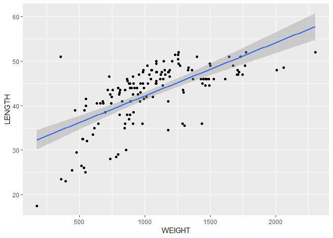

```r
plot.math4753Reg = function(x,...)
{
  print(x$g,...) # could use plot(etc)
}

plot(yreg)
```

We will now create another method. This time summary information for the ggplot.

Since `summary` is a generic function in base R we can use it.

```r
summary.math4753Reg = function(x,...)
{
  summary(x$g, ...)
}

summary(yreg)
```

```
## data: RIVER, MILE, SPECIES, LENGTH, WEIGHT, DDT [144x6]
## mapping:  x = ~WEIGHT, y = ~LENGTH
## faceting: <ggproto object: Class FacetNull, Facet, gg>
##     compute_layout: function
##     draw_back: function
##     draw_front: function
##     draw_labels: function
##     draw_panels: function
##     finish_data: function
##     init_scales: function
##     map_data: function
##     params: list
##     setup_data: function
##     setup_params: function
##     shrink: TRUE
##     train_scales: function
##     vars: function
##     super:  <ggproto object: Class FacetNull, Facet, gg>
## -----------------------------------
## geom_point: na.rm = FALSE
## stat_identity: na.rm = FALSE
## position_identity
##
## geom_smooth: na.rm = FALSE, se = TRUE
## stat_smooth: na.rm = FALSE, se = TRUE, method = lm, formula = y ~ x
## position_identity
```

# 5 Conclusion

The S3 OOP system is easy to use and flexible. The idea is to make an object containing all (or some major part) of the information you need for the analysis. Then extract from the object whatever you may need through appropriate methods.

The main function is a `constructor` and this will create objects of a certain class or classes.

A generic function will then inspect the object for the class of interest and then dispatch the method needed by way of a function called `method.class`

Here are the methods for our class `math4753Reg`

```r
methods(class = "math4753Reg")
```

```
## [1] plot    rsq     summary
## see '?methods' for accessing help and source code
```

# 6 Questions

Make an R function that acts as a constructor.

The function must do the following:

> 1. Take a data frame as one of its arguments.
> - The response is given and will be quantitative.
> - All other variables are assumed independent variables.
> 2. It must construct a complete first order model (including all interactions) for the data which is assumed the biggest model.
> 3. The step() function must be applied in all three directions and results stored for each.
> 4. All the output should be returned as an invisible list to be used by methods. `return(invisible(list(obj1name=obj1,obj2name=obj2)))`
> 5. The list output should be given the `class` name `MATH4773MLR`.
> 6. The function name will be `MYMLR`

Now use the generic function `plot` and create a method that will:

> 1. Plot the data (you may wish to use other packages to do this, pairs etc)
> 2. Plot each of the three models (how will you do this if there are more than two independent variables? You may use other packages etc)

Use the generic function `summary` and create a method that will:

> 1. compare the three models (numerical output)
> 2. summarize the three models (numerical output)
> 3. use the best model and then calculate cooks distance for all data
> 4. all the above can be placed in an invisible list.

There are a number of great packages available for you to use. Example `purrr` - this package enables you to rewrite complex iterative processes into a compact and sometimes faster running form. Functions like `try()` are good to use when errors are possible but you wish the script to continue running.

Try and make your data work on the following: Take `eval=FALSE` off the chunk options.

```r
mtcarsq=mtcars[,-c(8,9)] # remove categorical variables
methods(class="MATH4773MLR")
obj=MYMLR(data = mtcarsq, y="mpg")
plot(obj)
summary(obj)
```

# 7 Using `map` in `purrr`

The for loop can be replaced with various `map` functions. The following removes a multivariate datum then calculates estimates for the fitted model. For each model it calculates AIC and then sorts the result in increasing order. The indices are released from the sort function. This will tell us how well the model fits the data with the datum removed.

```r
library(purrr)
library(magrittr)
ylm = lm(mpg~.,data=mtcars)
dim(mtcars)[1]->n
lmm=map(1:n, ~lm(mpg~., data=mtcars[-.x,])) %>% map_dbl(.,~AIC(.x)) %>% sort(.,decreasing = FALSE, index=TRUE)
class(lmm)
```

```
## [1] "list"
```

```r
lmm
```

```
## $x
##  [1] 153.8049 154.2970 154.4386 154.5465 156.8526 157.3694 157.6016
##  [8] 158.1129 158.5757 158.6178 158.6511 158.7629 158.7935 159.1691
## [15] 159.4177 159.5474 159.5666 159.6613 159.6700 159.7633 159.9598
## [22] 160.0609 160.0853 160.2188 160.2355 160.2404 160.2484 160.3150
## [29] 160.3209 160.3258 160.3281 160.3281
##
## $ix
##  [1] 29 18 17 20  3 28 32  9 21 25 23  6 12  8 15  1 13 31 11 22  2  5 26
## [24] 19 10 16 14 27  4  7 30 24
```

```r
cks=sort(cooks.distance(ylm),decreasing = TRUE,index = TRUE)
cks
```

```
## $x
##      Ford Pantera L            Merc 230   Chrysler Imperial
##        7.135206e-01        3.792206e-01        1.461259e-01
##        Lotus Europa      Toyota Corolla       Toyota Corona
##        1.316870e-01        9.860340e-02        8.026150e-02
##            Fiat 128       Maserati Bora          Volvo 142E
##        7.356371e-02        7.309138e-02        6.581417e-02
##          Datsun 710          Merc 450SE             Valiant
##        6.352411e-02        4.013729e-02        3.697080e-02
##           Merc 240D  Cadillac Fleetwood    Pontiac Firebird
##        3.454201e-02        3.307570e-02        2.647385e-02
##           Merc 280C         AMC Javelin           Mazda RX4
##        2.404482e-02        2.124258e-02        2.059098e-02
##          Merc 450SL    Dodge Challenger       Mazda RX4 Wag
##        1.101611e-02        9.609258e-03        9.218355e-03
##         Honda Civic            Merc 280   Hornet Sportabout
##        7.045139e-03        4.282385e-03        4.083138e-03
##           Fiat X1-9 Lincoln Continental         Merc 450SLC
##        2.467984e-03        2.411065e-03        1.412179e-03
##       Porsche 914-2      Hornet 4 Drive          Duster 360
##        1.329399e-03        1.306707e-04        6.907413e-05
##          Camaro Z28        Ferrari Dino
##        5.466773e-07        5.198424e-07
##
## $ix
##  [1] 29  9 17 28 20 21 18 31 32  3 12  6  8 15 25 11 23  1 13 22  2 19 10
## [24]  5 26 16 14 27  4  7 24 30
```

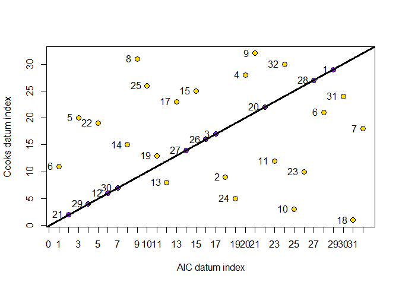

```r
cll = ifelse(cks$ix==lmm$ix, "Purple", "Gold")
plot(lmm$ix,cks$ix,type="p", bg=cll, pch=21, cex=1.2, xlab = "AIC datum index", ylab="Cooks datum index")
axis(1, 1:n[cks$ix==lmm$ix])
abline(coef=c(0,1),lwd=3)
text(lmm$ix, cks$ix, 1:n, pos=2)
```

```r
# caculating the maximal model
ymax = lm(mpg~.^2,data=mtcars[,-c(2,3,8,9)])
head(mtcars)
```

```
##                    mpg cyl disp  hp drat    wt  qsec vs am gear carb
## Mazda RX4         21.0   6  160 110 3.90 2.620 16.46  0  1    4    4
## Mazda RX4 Wag     21.0   6  160 110 3.90 2.875 17.02  0  1    4    4
## Datsun 710        22.8   4  108  93 3.85 2.320 18.61  1  1    4    1
## Hornet 4 Drive    21.4   6  258 110 3.08 3.215 19.44  1  0    3    1
## Hornet Sportabout 18.7   8  360 175 3.15 3.440 17.02  0  0    3    2
## Valiant           18.1   6  225 105 2.76 3.460 20.22  1  0    3    1
```

```r
#car::vif(ymax)
step(ymax,direction = "backward")
```

```
## Start:  AIC=24.7
## mpg ~ (hp + drat + wt + qsec + gear + carb)^2
##
##             Df Sum of Sq    RSS    AIC
## - drat:carb  1    0.0216 17.530 22.741
## - gear:carb  1    0.0375 17.546 22.770
## <none>                   17.508 24.702
## - drat:gear  1    1.1570 18.665 24.750
## - wt:carb    1    1.1957 18.704 24.816
## - hp:wt      1    1.4838 18.992 25.305
## - qsec:gear  1    2.7117 20.220 27.310
## - qsec:carb  1    3.2873 20.796 28.208
## - hp:qsec    1    9.9524 27.461 37.105
## - hp:carb    1   11.4813 28.990 38.838
## - drat:qsec  1   11.9391 29.447 39.340
## - hp:gear    1   17.8803 35.389 45.221
## - drat:wt    1   24.4590 41.967 50.677
## - wt:gear    1   25.9595 43.468 51.801
## - wt:qsec    1   26.3111 43.819 52.059
## - hp:drat    1   29.9245 47.433 54.595
##
## Step:  AIC=22.74
## mpg ~ hp + drat + wt + qsec + gear + carb + hp:drat + hp:wt +
##     hp:qsec + hp:gear + hp:carb + drat:wt + drat:qsec + drat:gear +
##     wt:qsec + wt:gear + wt:carb + qsec:gear + qsec:carb + gear:carb
##
##             Df Sum of Sq    RSS    AIC
## - gear:carb  1    0.2235 17.753 21.147
## <none>                   17.530 22.741
## - wt:carb    1    1.1923 18.722 22.847
## - hp:wt      1    1.5595 19.089 23.469
## - drat:gear  1    2.2293 19.759 24.572
## - qsec:carb  1    3.4437 20.974 26.481
## - qsec:gear  1    5.5195 23.049 29.501
## - hp:carb    1   12.8275 30.357 38.314
## - hp:qsec    1   13.3875 30.917 38.899
## - drat:qsec  1   19.4630 36.993 44.640
## - hp:gear    1   22.0925 39.622 46.837
## - wt:qsec    1   28.7206 46.250 51.787
## - wt:gear    1   29.9306 47.460 52.613
```

[output cut: 47 more lines]

```
##     wt:gear + qsec:gear + qsec:carb
##
##             Df Sum of Sq    RSS    AIC
## <none>                   19.206 19.664
## - drat:gear  1     1.755 20.961 20.462
## - qsec:carb  1     3.659 22.865 23.245
## - qsec:gear  1     6.440 25.646 26.917
## - hp:qsec    1    15.260 34.467 36.376
## - drat:qsec  1    22.425 41.631 42.420
## - hp:gear    1    36.875 56.082 51.954
## - hp:carb    1    37.126 56.332 52.097
## - wt:qsec    1    43.114 62.320 55.330
## - drat:wt    1    49.000 68.206 58.218
## - hp:drat    1    50.941 70.148 59.116
## - wt:gear    1    52.900 72.107 59.997
```

```
##
## Call:
## lm(formula = mpg ~ hp + drat + wt + qsec + gear + carb + hp:drat +
##     hp:qsec + hp:gear + hp:carb + drat:wt + drat:qsec + drat:gear +
##     wt:qsec + wt:gear + qsec:gear + qsec:carb, data = mtcars[,
##     -c(2, 3, 8, 9)])
##
## Coefficients:
## (Intercept)           hp         drat           wt         qsec
##  -532.62099      1.07417     75.49098     60.03772     29.70940
##        gear         carb      hp:drat      hp:qsec      hp:gear
##   -17.77022     13.17002     -0.31843     -0.02246      0.13311
##     hp:carb      drat:wt    drat:qsec    drat:gear      wt:qsec
##    -0.03652     15.84210     -5.06951      2.28492     -4.17741
##     wt:gear    qsec:gear    qsec:carb
##   -11.65688      1.63642     -0.46266
```

```r
head(mtcars)
```

```
##                    mpg cyl disp  hp drat    wt  qsec vs am gear carb
## Mazda RX4         21.0   6  160 110 3.90 2.620 16.46  0  1    4    4
## Mazda RX4 Wag     21.0   6  160 110 3.90 2.875 17.02  0  1    4    4
## Datsun 710        22.8   4  108  93 3.85 2.320 18.61  1  1    4    1
## Hornet 4 Drive    21.4   6  258 110 3.08 3.215 19.44  1  0    3    1
## Hornet Sportabout 18.7   8  360 175 3.15 3.440 17.02  0  0    3    2
## Valiant           18.1   6  225 105 2.76 3.460 20.22  1  0    3    1
```

```r
final=step(ymax,direction="backward")
```

```
## Start:  AIC=24.7
## mpg ~ (hp + drat + wt + qsec + gear + carb)^2
##
##             Df Sum of Sq    RSS    AIC
## - drat:carb  1    0.0216 17.530 22.741
## - gear:carb  1    0.0375 17.546 22.770
## <none>                   17.508 24.702
## - drat:gear  1    1.1570 18.665 24.750
## - wt:carb    1    1.1957 18.704 24.816
## - hp:wt      1    1.4838 18.992 25.305
## - qsec:gear  1    2.7117 20.220 27.310
## - qsec:carb  1    3.2873 20.796 28.208
## - hp:qsec    1    9.9524 27.461 37.105
## - hp:carb    1   11.4813 28.990 38.838
## - drat:qsec  1   11.9391 29.447 39.340
## - hp:gear    1   17.8803 35.389 45.221
## - drat:wt    1   24.4590 41.967 50.677
## - wt:gear    1   25.9595 43.468 51.801
## - wt:qsec    1   26.3111 43.819 52.059
## - hp:drat    1   29.9245 47.433 54.595
##
## Step:  AIC=22.74
## mpg ~ hp + drat + wt + qsec + gear + carb + hp:drat + hp:wt +
##     hp:qsec + hp:gear + hp:carb + drat:wt + drat:qsec + drat:gear +
##     wt:qsec + wt:gear + wt:carb + qsec:gear + qsec:carb + gear:carb
##
##             Df Sum of Sq    RSS    AIC
## - gear:carb  1    0.2235 17.753 21.147
## <none>                   17.530 22.741
## - wt:carb    1    1.1923 18.722 22.847
## - hp:wt      1    1.5595 19.089 23.469
## - drat:gear  1    2.2293 19.759 24.572
## - qsec:carb  1    3.4437 20.974 26.481
## - qsec:gear  1    5.5195 23.049 29.501
## - hp:carb    1   12.8275 30.357 38.314
## - hp:qsec    1   13.3875 30.917 38.899
## - drat:qsec  1   19.4630 36.993 44.640
## - hp:gear    1   22.0925 39.622 46.837
## - wt:qsec    1   28.7206 46.250 51.787
## - wt:gear    1   29.9306 47.460 52.613
```

[output cut: 47 more lines]

```
##     wt:gear + qsec:gear + qsec:carb
##
##             Df Sum of Sq    RSS    AIC
## <none>                   19.206 19.664
## - drat:gear  1     1.755 20.961 20.462
## - qsec:carb  1     3.659 22.865 23.245
## - qsec:gear  1     6.440 25.646 26.917
## - hp:qsec    1    15.260 34.467 36.376
## - drat:qsec  1    22.425 41.631 42.420
## - hp:gear    1    36.875 56.082 51.954
## - hp:carb    1    37.126 56.332 52.097
## - wt:qsec    1    43.114 62.320 55.330
## - drat:wt    1    49.000 68.206 58.218
## - hp:drat    1    50.941 70.148 59.116
## - wt:gear    1    52.900 72.107 59.997
```

```r
class(final)
```

```
## [1] "lm"
```

```r
summary(final)
```

```
##
## Call:
## lm(formula = mpg ~ hp + drat + wt + qsec + gear + carb + hp:drat +
##     hp:qsec + hp:gear + hp:carb + drat:wt + drat:qsec + drat:gear +
##     wt:qsec + wt:gear + qsec:gear + qsec:carb, data = mtcars[,
##     -c(2, 3, 8, 9)])
##
## Residuals:
##      Min       1Q   Median       3Q      Max
## -1.84214 -0.38156 -0.04585  0.34626  1.68163
##
## Coefficients:
##               Estimate Std. Error t value Pr(>|t|)
## (Intercept) -5.326e+02  1.148e+02  -4.638 0.000384 ***
## hp           1.074e+00  2.175e-01   4.938 0.000218 ***
## drat         7.549e+01  2.693e+01   2.804 0.014078 *
## wt           6.004e+01  1.201e+01   4.998 0.000195 ***
## qsec         2.971e+01  5.557e+00   5.346 0.000103 ***
## gear        -1.777e+01  1.584e+01  -1.122 0.280654
## carb         1.317e+01  5.354e+00   2.460 0.027510 *
## hp:drat     -3.184e-01  5.226e-02  -6.094 2.77e-05 ***
## hp:qsec     -2.246e-02  6.733e-03  -3.335 0.004906 **
## hp:gear      1.331e-01  2.567e-02   5.185 0.000138 ***
## hp:carb     -3.652e-02  7.021e-03  -5.202 0.000134 ***
## drat:wt      1.584e+01  2.651e+00   5.976 3.39e-05 ***
## drat:qsec   -5.070e+00  1.254e+00  -4.043 0.001210 **
## drat:gear    2.285e+00  2.020e+00   1.131 0.277075
## wt:qsec     -4.177e+00  7.452e-01  -5.606 6.48e-05 ***
## wt:gear     -1.166e+01  1.877e+00  -6.210 2.28e-05 ***
## qsec:gear    1.636e+00  7.553e-01   2.167 0.048013 *
## qsec:carb   -4.627e-01  2.833e-01  -1.633 0.124719
## ---
## Signif. codes:  0 '***' 0.001 '**' 0.01 '*' 0.05 '.' 0.1 ' ' 1
##
## Residual standard error: 1.171 on 14 degrees of freedom
## Multiple R-squared:  0.9829, Adjusted R-squared:  0.9622
## F-statistic: 47.46 on 17 and 14 DF,  p-value: 1.776e-09
```